# Weighted and non-weighted Spectral Clustering

Rhian Davies

6 August 2016

Observing affinity matricies for weighted and unweighted spectral clustering.

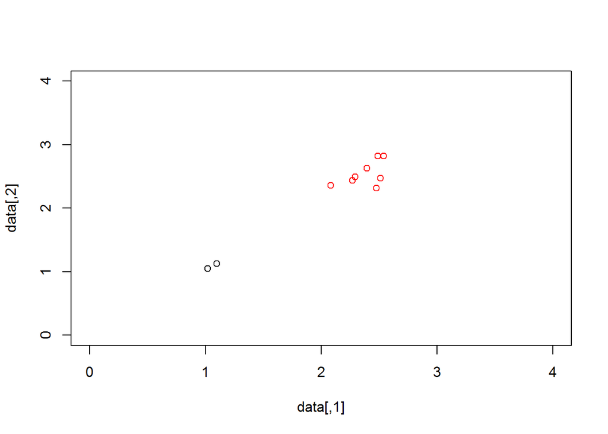

We apply k-means to create two microclusters

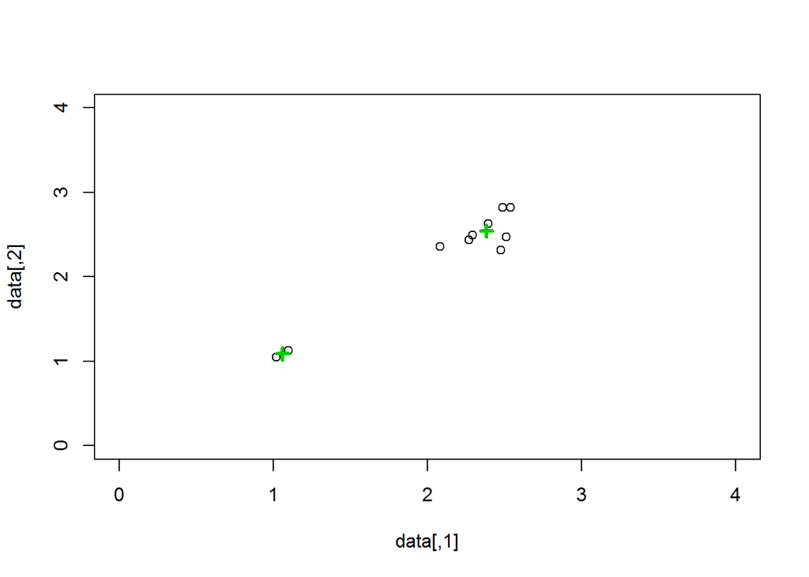

The centers of the microclusters are 1.1, 1.1 and 2.4, 2.5 . Therefore a simple affinity matrix can be created for those two points.

The affinity matrix is given below.

$\mathbf{A} = \left[\begin{array} {rrr} 1 & 0.1396712 \\ 0.1396712 & 1 \end{array}\right]$

We then calculate the diagonal and the Laplacian matricies

$\mathbf{D} = \left[\begin{array} {rrr} 1.1396712 & 0 \\ 0 & 1.1396712 \end{array}\right]$

$\mathbf{L} = \left[\begin{array} {rrr} 0.1396712 & -0.1396712 \\ -0.1396712 & 0.1396712 \end{array}\right]$

### Weighting the affinity matrix

There are 2 points assigned to cluster 1 and 8 points assigned to cluster 2. We can weight the affinity matrix by the number of elements in each cluster.

Note that we no longer have ones on the diagonal although the matrix is still positive semi definite and symmetric. (And will always be when we multiply by a positive number)

$\mathbf{A} = \left[\begin{array} {rrr} 4 & 2.2347391 \\ 2.2347391 & 64 \end{array}\right]$

We then calculate the diagonal and the Laplacian matricies

$\mathbf{D} = \left[\begin{array} {rrr} 6.2347391 & 0 \\ 0 & 66.2347391 \end{array}\right]$

$\mathbf{L} = \left[\begin{array} {rrr} 2.2347391 & -2.2347391 \\ -2.2347391 & 2.2347391 \end{array}\right]$

Weighting the microclusters in this manner is the same as treating creating an affinity matrix with each microcluster center repeated as many times as there are points.

For example in this very simple case the Affinity matrix would be…

|  | A | B | C | D | E | F | G | H | I | J |
| --- | --- | --- | --- | --- | --- | --- | --- | --- | --- | --- |
| A | 1.0000000 | 1.0000000 | 0.1396712 | 0.1396712 | 0.1396712 | 0.1396712 | 0.1396712 | 0.1396712 | 0.1396712 | 0.1396712 |
| B | 1.0000000 | 1.0000000 | 0.1396712 | 0.1396712 | 0.1396712 | 0.1396712 | 0.1396712 | 0.1396712 | 0.1396712 | 0.1396712 |
| C | 0.1396712 | 0.1396712 | 1.0000000 | 1.0000000 | 1.0000000 | 1.0000000 | 1.0000000 | 1.0000000 | 1.0000000 | 1.0000000 |
| D | 0.1396712 | 0.1396712 | 1.0000000 | 1.0000000 | 1.0000000 | 1.0000000 | 1.0000000 | 1.0000000 | 1.0000000 | 1.0000000 |
| E | 0.1396712 | 0.1396712 | 1.0000000 | 1.0000000 | 1.0000000 | 1.0000000 | 1.0000000 | 1.0000000 | 1.0000000 | 1.0000000 |
| F | 0.1396712 | 0.1396712 | 1.0000000 | 1.0000000 | 1.0000000 | 1.0000000 | 1.0000000 | 1.0000000 | 1.0000000 | 1.0000000 |
| G | 0.1396712 | 0.1396712 | 1.0000000 | 1.0000000 | 1.0000000 | 1.0000000 | 1.0000000 | 1.0000000 | 1.0000000 | 1.0000000 |
| H | 0.1396712 | 0.1396712 | 1.0000000 | 1.0000000 | 1.0000000 | 1.0000000 | 1.0000000 | 1.0000000 | 1.0000000 | 1.0000000 |
| I | 0.1396712 | 0.1396712 | 1.0000000 | 1.0000000 | 1.0000000 | 1.0000000 | 1.0000000 | 1.0000000 | 1.0000000 | 1.0000000 |
| J | 0.1396712 | 0.1396712 | 1.0000000 | 1.0000000 | 1.0000000 | 1.0000000 | 1.0000000 | 1.0000000 | 1.0000000 | 1.0000000 |